# Getting started with SIDEREF

## Introduction

In this brief article, we demonstrate the SIDEREF analysis pipeline using a set of preprocessed scRNA seq data from Seurat.

SIDEREF is demonstrated to more reliably compute summarized distances between cell types. In particular one can leverage this information to compare broadly defined cell types, such as leukocytes, to narrowly defined cell types, such as B cells and T cells, as well as simply examining how related the well-defined cell types are to each other. Additionally, one could consider computing SIDEREF on manually selected gene modules to see how this impacts the cell type level distances. In this vignette, we demonstrate the first mentioned use case.

We provide a sample of of the Tabula Muris (TM) droplet scRNA seq data, used in the main analysis. If you would like to download and process this data for yourself, see `README.md`, `R/download_data.R` for data downloading, and `R/tm_combine_raw.R`, `R/tm_preproc.R` for data processing. For the analysis in this vignette, we want annotated cell types to compare against each other. To provide an initial cell type annotation of fresh scRNA seq data, one popular pipeline is through the [Seurat package](https://satijalab.org/seurat/articles/pbmc3k_tutorial.html#cluster-the-cells-1)

## Subsampling and Preprocessing TM data

Below, for demonstration, we show the process of loading the preprocessed  
TM droplet expression matrix and metadata, and subsampling by cell type. If your data is $<3000$ cells, you may go ahead and run SIDEREF (taking advantage of default parallelization). Otherwise, we find that for the ~55,000 cell TM data, subsampling 100 cells per cell type is sufficient to recover stable cell type relative distances.

```r
load(here("output/tab_muris_sc/tab_muris_full.RData"),
     verbose=TRUE)

### Set constants
cell_type_sample_size <- 100
n_variable_genes <- 3000

### B Cell, T Cell leukocyte extraction
cell_types_of_interest <- c("B cell", "natural killer cell", "leukocyte",
                            "bladder cell")

### For T.M. data, we want distinct celltype, tissue combinations.
### Note: This column is in fact already stored in the data as ``group_label``
meta_data_full <-
  meta_data_full %>%
  dplyr::mutate(cell_type_tissue = str_to_title(paste(cell_type, tissue, sep = ", ")))

cell_types_tissues_of_interest <-
  meta_data_full %>%
  dplyr::filter(cell_type %in% cell_types_of_interest) %>%
  dplyr::pull(cell_type_tissue) %>% unique()


cells_sample_idx <- c()

### Sample one cell type at a time and append to ID list.
for(ct_tiss in cell_types_tissues_of_interest) {
  cell_type_idx <-
      which(meta_data_full$cell_type_tissue %in% ct_tiss)

  cells_sample_idx <-
    c(cells_sample_idx,
      sample(cell_type_idx,
             min(length(cell_type_idx), cell_type_sample_size)))
}

### Subset the data and metadata objects
data_subset <- data_full[ , cells_sample_idx]
meta_data_subset <- meta_data_full[cells_sample_idx, ]

### Seurat Package can yield us the 3,000 most variable genes for our group
###   and preprocess the data.
data_subset_seurat <-
  CreateSeuratObject(data_subset, project = "SeuratProject", assay = "RNA")

### Getting the variable genes
data_subset_seurat <-
  FindVariableFeatures(data_subset_seurat, nfeatures = n_variable_genes)

### Preprocessing the data
data_subset_seurat <-
  NormalizeData(data_subset_seurat)
data_subset_seurat <-
  ScaleData(data_subset_seurat)

data_subset_variable <- data_subset_seurat@assays$RNA@scale.data

### Confirm the dimensions look okay.
### Note: for several cell types, there are less cells than the subsample size.
dim(data_subset_variable)

## Now we will save the two objects as an RData that is available on the repo.
save(data_subset_variable, meta_data_subset,
     file = here("output/tab_muris_sc/vignette_data/tm_sample.RData"))

## RM large tm objects and conserve space
rm(list = c("data_full", "meta_data_full", "data_subset_seurat"))
```

## Running SIDEREF

The preprocessed sample data in the chunk above is available on the GitHub repository. Feel free to run the code for yourself to explore the cell type subsampling procedure (and Seurat preprocessing steps) or simply review.

Now, we will reload the data and run `SIDEREF()` on the preprocessed gene expression matrix, which returns the symmetric distance matrix.

```r
load(here("output/tab_muris_sc/vignette_data/tm_sample.RData"),
     verbose = TRUE)
```

```
## Loading objects:
##   data_subset_variable
##   meta_data_subset
```

```r
### SIDEREF
### Note: source(here("R/libraries.R")) loads the function but we may also load it using:
source(here("R/SIDEREF.R"))

sideref_res <- SIDEREF(data_subset_variable)
```

```
## Cores in usage: 6Running averaging iteration 1 of 1 ...
```

### SIDEREF Options

Note that the only required argument of SIDEREF is the expression matrix. You may consider changing some of the default arguments:

- n_top_genes (300): Number of genes comprising each DE gene list.
- R (100): Size of cell reference set.
- return_sim (FALSE): If true, returns the similarity matrix.
- parallelize (TRUE): Whether to parallelize computations.
- n_cores (detectCores()-2): How many cores to use in the parallel computation.
- verbose (TRUE): Whether to print status messages during SIDEREF computation.

For other parameters, we generally recommend leaving in their default setting, or it should not make a very meaningfully difference in the generated results.

## Computing relative distances

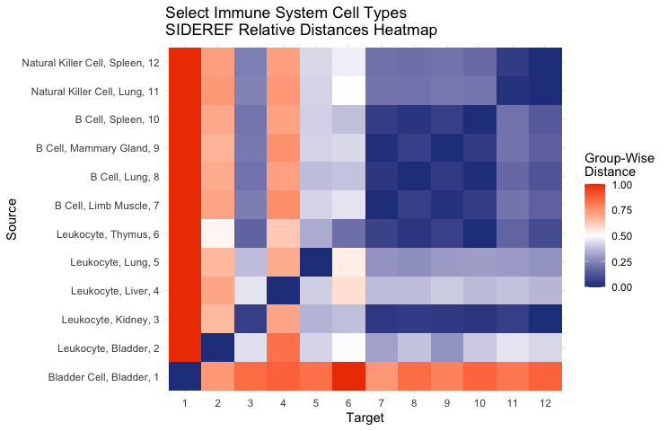

```r
source(here('R/relative_group_dist_comps.R'))

## Note: meta_data has a 'group_label' column containing cell type and tissue
## Note: meta_data column should have cells in the same order as the dist matrix.

### We may have an ordering that we prefer for the heatmap
group_labels <- as.character(meta_data_subset$group_label)

preset_levels <-
  c(
    unique(group_labels[grepl("Bladder Cell", group_labels)]),
    unique(group_labels[grepl("Leukocyte", group_labels)]),
    unique(group_labels[grepl("B Cell", group_labels)]),
    unique(group_labels[grepl("Natural Killer", group_labels)])

    )

groupwiseDistanceHeatmap(
  group_labels = group_labels,
  dist_mat = sideref_res,
  title = "Select Immune System Cell Types\nSIDEREF Relative Distances Heatmap",
  do_hclust_axes = FALSE,
  preset_levels = preset_levels,
  do_numeric_x=TRUE,
  do_numeric_y=FALSE
  )
```

Rows designate *Source to Target* distance. These rows always include at least one value of 1 and one value of 0, and denote the relative closeness of each cell type to the source group. In contrast, the *Target to Source* columns may not include 0 or 1, and denote the relative closeness of the target group to each source group. For example, the bladder cells are always the most distal target group, so its target column values are all 1. However, of course it has some cell types that lie closer to it than others, so its row values are more variable. For example, its smallest source to target distance are clearly the bladder leukocytes. In this sense the row and column for the bladder cell type provide complementary information about its global relations.

In the SIDEREF manuscript, we conduct gene set enrichment analysis (GSEA) to validate that Thymus and Kidney leukocytes are enriched for B cell DE genes. With Natural Killer (NK) cells included, we interestingly see that Kidney leukocytes are proximal to the NK cell groups as well as the B cell groups. As leukocytes can consist of any of its composite narrow immune cell types, it is possible that some cells in this group are NK cells and some B cells. Both of these cell types derive from lymphoid progenitors. We might consider partitioning the kidney leukocytes into subgroups based such that relative distances are minimal to B cells for one subgroup and to NK cells for the other subgroup. Such analysis was out of the scope of the manuscript but is an interesting direction to consider for automated cell type annotation.

Note that we specify an ordering of the cell types using argument `preset_levels`. If you would like hierarchical clustering applied to the heatmap in order to label cell types in an automated fashion, you may set  
`do_hclust_axes = TRUE`:

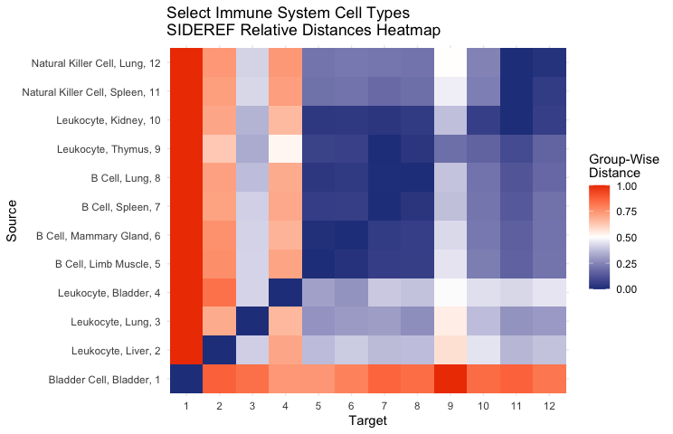

```r
groupwiseDistanceHeatmap(
  group_labels = group_labels,
  dist_mat = sideref_res,
  title = "Select Immune System Cell Types\nSIDEREF Relative Distances Heatmap",
  do_hclust_axes = TRUE,
  preset_levels = NULL,
  do_numeric_x=TRUE,
  do_numeric_y=FALSE
  )
```

[figure not shown]

```r
source(here("R/bipartite_graphs.R"))

bipartiteNetworkGraph(
        dist_mat = sideref_res,
        group_labels = group_labels,
        preset_levels = preset_levels,
        source_groups = "Leukocyte, Kidney",
        title = "Bladder Tissue Leukocytes, Source-Target Distances",
        two_color_grad = TRUE,
        ## text-sizing options:
        node_size = 7.5,
        text_size = 3,
        s_t_size = 4,
        leg_text_size = 8,
        legend_title = "Cell Type, Tissue") +
  theme(legend.key.size = unit(0.5, 'cm'))
```

Argument `two_color_grad` will maintain the red-white-blue gradient if `FALSE` and impose a white-blue gradient if `TRUE`:

[figure not shown]

```r
bipartiteNetworkGraph(
        dist_mat = sideref_res,
        group_labels = group_labels,
        preset_levels = preset_levels,
        source_groups = "Leukocyte, Kidney",
        title = "Bladder Tissue Leukocytes, Source-Target Distances",
        two_color_grad = FALSE,
        ## text-sizing options:
        node_size = 7.5,
        text_size = 3,
        s_t_size = 4,
        leg_text_size = 8,
        legend_title = "Cell Type, Tissue") +
  theme(legend.key.size = unit(0.6, 'cm'))
```